# Volatility Comparison

SW Wellmann

November 2022

# 1 Volatility Comparison

First we have to load in the data and do some data manipulations:

We first plot the returns over time to see if there are any outliers and how large they are. Below we can see there are some with large outliers but nothing too major so we will not limit the data.

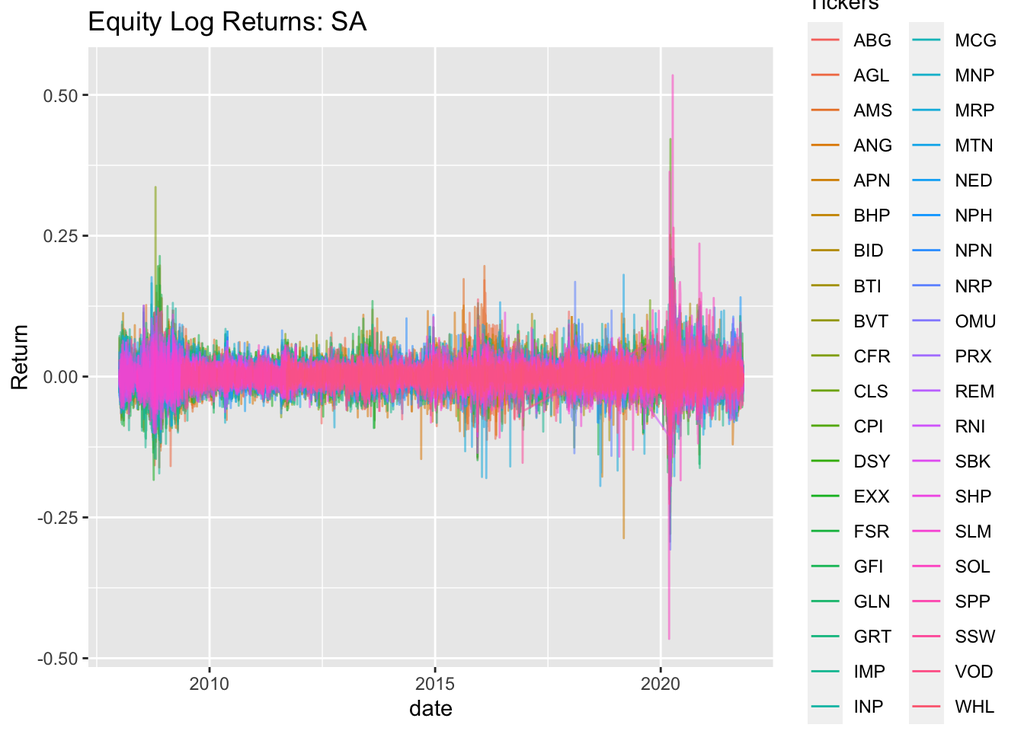

We need wide data to find the PCA’s. There are NA values in the data so we use the impute_missing_returns function from Question 3. We impute values according to own distribution as if we impute across the whole dataframe it will bias the PCA analysis.

## 1.1 PCA

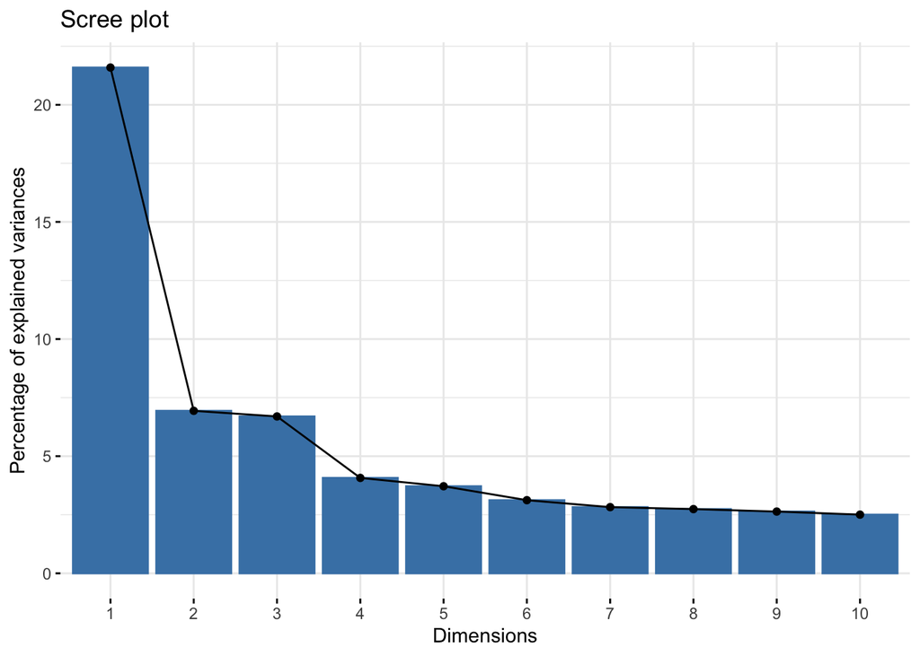

The figure below shows how the individual stocks contribute to the first PCA factor. This first PCA factor explains 20 percent of the movement of the top 40 index. Interestingly, in this PCA factor, one can see the largest contributors are SBK (Standard Bank), FSR (FirstRand), NED (Nedbank), ABG (Absa), REM (Remgro), SLM (Sanlam) and INP (Investec). These are all part of financials and are mostly banks. If correlated financials constitute a large part of the top 40, then we can use these as PCA’s to explain the variation of the top 40.

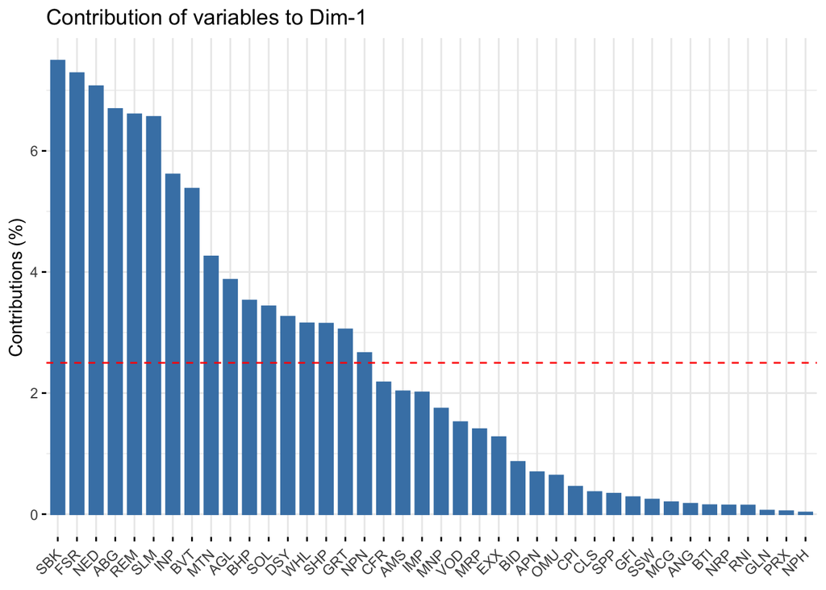

We do the same as above except for the second PCA. The contribution percentages are a bit higher here with Nepi Rockcastle (NRP) having the most influence.

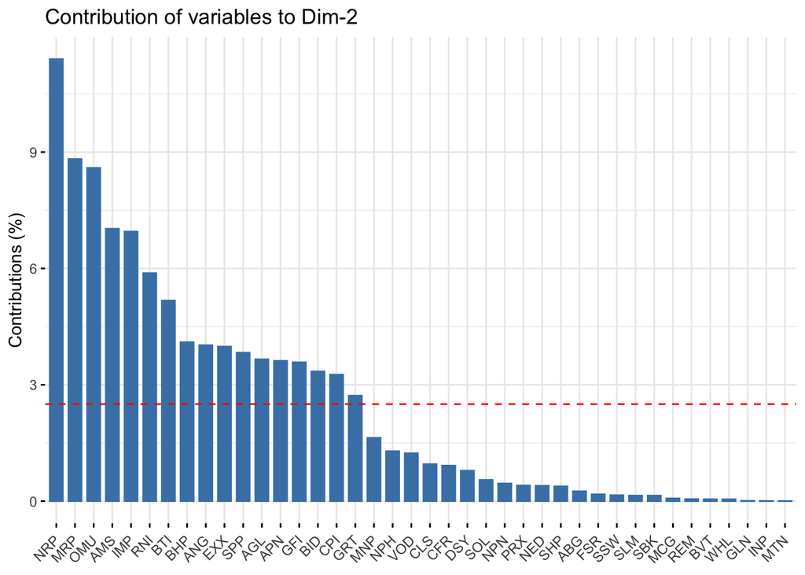

We now visualise the direction of the variables across the first and second PCA.

The following figure shows which stocks contribute to PCA 1 and PCA 2. The stocks drive largely in the same direction for the first dimension but vary quite a bit in the second. This shows opportunity for diversification in the second dimension.

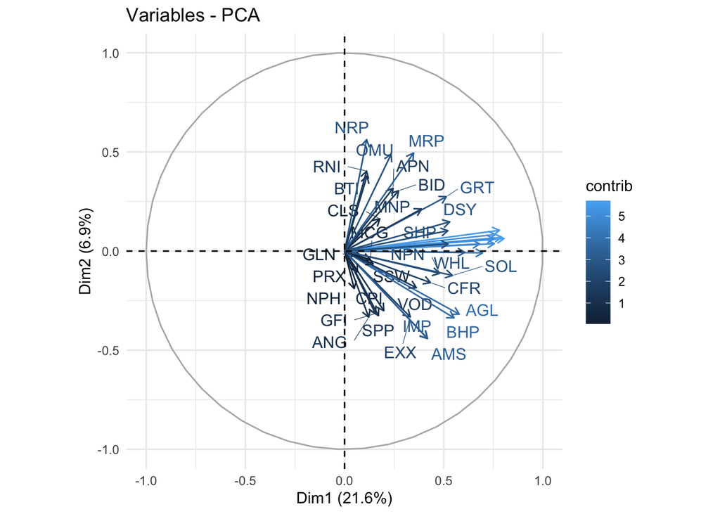

## 1.2 Constituent correlations

To calculate constituent correlations through time I calculate the correlation matrix of the top 40 constituents in the ALSI, which derived from a Ledoit-Wolf shrunk matrix. I then use the auxiliary functions loaded from Nico’s gist.

Below we have complex comovement structures using a dendogram, colouring several groups that are of note.

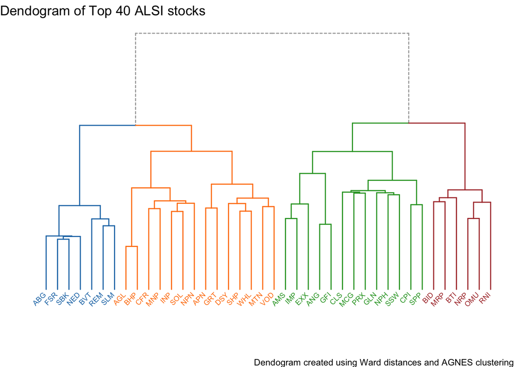

## 1.3 Stratify for periods of high volatility

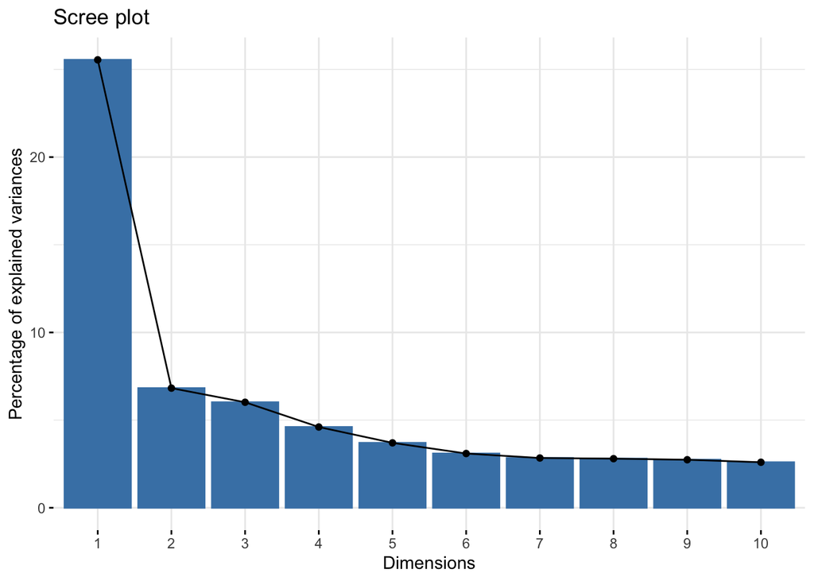

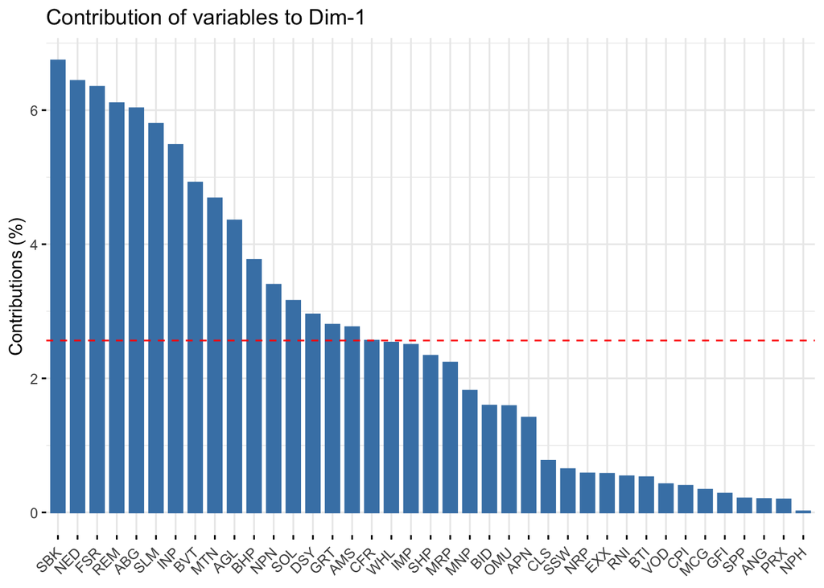

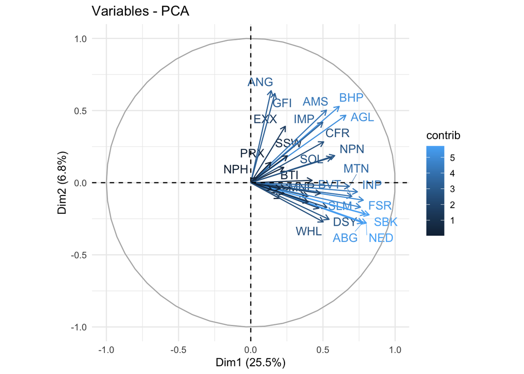

Below we have complex comovement structures using a dendogram, colouring several groups that are of note.

[figure not shown]